# Atlantis Diagnostics Development Documentation

Sarah Gaichas

17 January, 2020

## Intro

Here we document the development Atlantis diagnostics code to determine whether the model is meeting define performance and review criteria. Code we be developed to evaluate the model output against detailed performance criteria developed in [1] and the calibration criteria in [2]:

1. All functional groups persist
2. Model stabilizes for the last ~20 years of an unfished, unperturbed 80-100 year run
3. Details for calibration:
   - Unfished system:
     - produce stable biomass through time under stable-environmental forcing
     - keep all groups from going extinct
     - obtain stable biomasses that are not oscillating more than a certain percentage from initial values
   - System with constant fishing: reproduce realistic responses to a range of fishing pressures
4. Hindcast period established where we have survey/assessment time series with error bounds
5. Species groups totaling ~80% of system biomass should qualitatively match hindcast biomass trends. During calibration: reproduce historical trends in biomass when forcing the model with historical fishing and environmental drivers.
6. Patterns of temporal variability captured (emergent or forced with e.g. recruitment time series)
7. Productivity for groups totaling ~80% of system biomass should qualitatively match FMSY or life history expectations
8. Natural mortality decreases with age for majority of groups
9. Age and length structure qualitatively matches expectations for majority of groups
10. Diet predicted qualitatively matches empirical diet comp for majority of groups

An R function for each criterion is developed below, and a wrapper that runs all functions will be developed and tested here.

We use these R libraries, with non-CRAN package installation instructions in comments.

```r
#devtools::install_github("noaa-edab/ecodata",build_vignettes=TRUE)
# suggested to use remotes::install_github instead
#devtools::install_github("r4atlantis/atlantisom")
# devtools::install_local('C:/Users/joseph.caracappa/Documents/GitHub/atlantisom/')
# remotes::install_github("noaa-edab/ecotrend")

library(ecodata)
library(ecotrend)
library(tidyverse)
library(atlantisom)
library(here)
source("shift_legend.R")
```

Configure files to be read in here (can have different files to source)

```r
# set up files to be read in
# the below can go into a config file to be sourced

d.name <- here("diagnostics", "testfiles",'50_year_no_fishing') #folder with files below; e.g. here("atlantisoutput","currentrun")
functional.groups.file <- "NeusGroups_v15_unix_RM.csv"
biomass.pools.file <- "atneus_v15_test2008hydro_20180208.nc"
biol.prm.file <- "at_biol_neus_v15_scaled_diet_20190924_2.xml"
box.file <- "neus_tmerc_RM2.bgm"
initial.conditions.file <- "RMinit4_2019.nc"
run.prm.file <- "at_run_neus_v15_RM_scale_0503_nofishing.xml"
scenario.name <- "atneus_v15_JC_testv6490_nofishing"
bioind.file <- "atneus_v15_JC_testv6490_nofishingBiomIndx.txt"
# catch.file <- "atneus_v15_test2008hydro_20180208Catch.txt"
```

Get functional group names for other functions

```r
#Load functional groups
funct.groups <- load_fgs(dir=d.name,
                         file_fgs = functional.groups.file)
#Get just the names of active functional groups
funct.group.names <- funct.groups %>%
  filter(IsTurnedOn == 1) %>%
  select(Name) %>%
  .$Name
```

Get basic output parameters

```r
# should return all model areas
boxpars <- load_box(d.name, box.file)
boxall <- c(0:(boxpars$nbox - 1))

# generalized timesteps all models
runpar <- load_runprm(d.name, run.prm.file)
noutsteps <- runpar$tstop/runpar$outputstep
stepperyr <- if(runpar$outputstepunit=="days") 365/runpar$toutinc
midptyr <- round(median(seq(0,stepperyr)))

# a survey that takes place once per year mid year
annualmidyear <- seq(midptyr, noutsteps, stepperyr)

timeall <- c(0:noutsteps)

# learned the hard way this can be different from ecosystem outputs
fstepperyr <- if(runpar$outputstepunit=="days") 365/runpar$toutfinc
```

### Persistence test

This should be run on an **unfished, unperturbed** run. Fishing or perturbations may legitimately drive groups extinct.

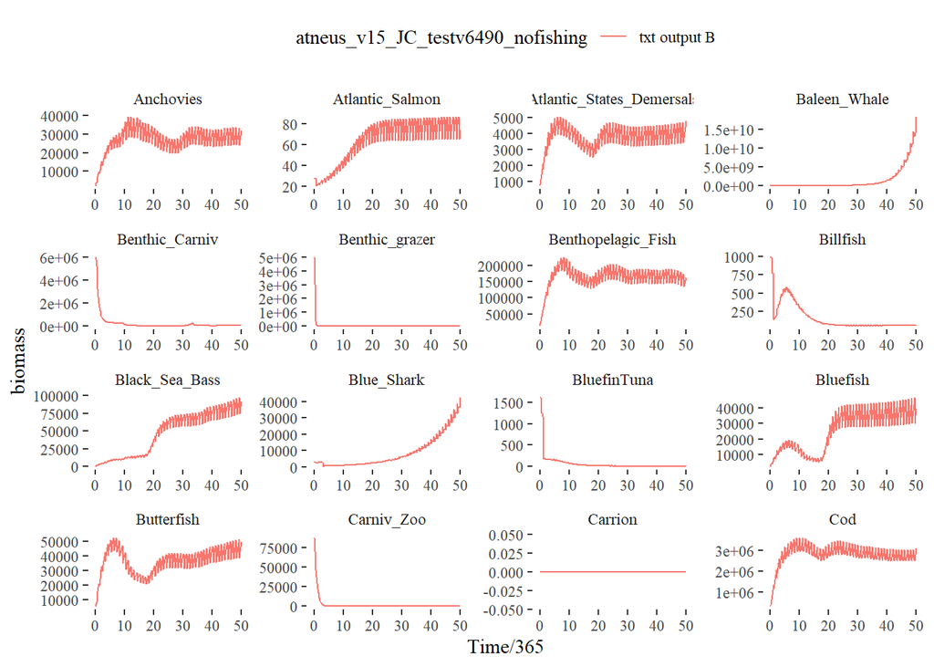

```r
# read the output atlantis biom.txt file

atBtxt <- read.table(file.path(d.name, paste0(scenario.name, "BiomIndx.txt")), header=T)
groupslookup <- funct.groups %>%
  filter(IsTurnedOn > 0)

atBtxttidy <- atBtxt %>%
  select(Time:DIN) %>%
  rename_(.dots=with(groupslookup, setNames(as.list(as.character(Code)), Name))) %>%
  gather(species, biomass, -Time) %>%
  mutate(yr = ceiling(Time/365))  # assumes BiomInd.txt time unit is days leaves initial time 0 on its own

# visualize; hardcoded pages for ~89 group model

plotB <-ggplot() +
  geom_line(data=atBtxttidy, aes(x=Time/365,y=biomass, color="txt output B"),
             alpha = 10/10) +
  ggthemes::theme_tufte() +
  theme(legend.position = "top") +
  labs(colour=scenario.name)

plotB + ggforce::facet_wrap_paginate(~species, ncol=4, nrow = 4, page = 1, scales="free")
```

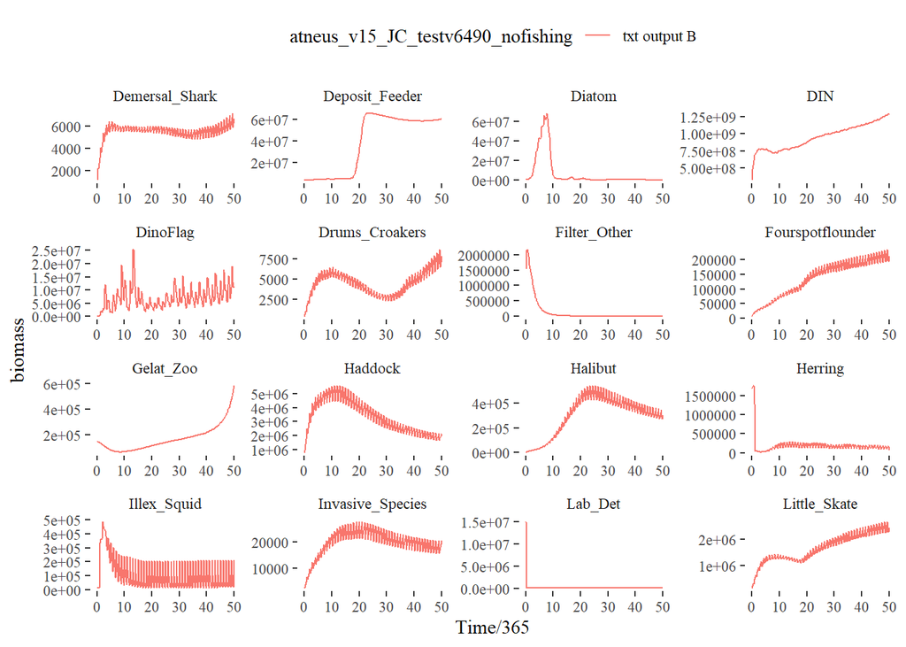

```r
plotB + ggforce::facet_wrap_paginate(~species, ncol=4, nrow = 4, page = 2, scales="free")
```

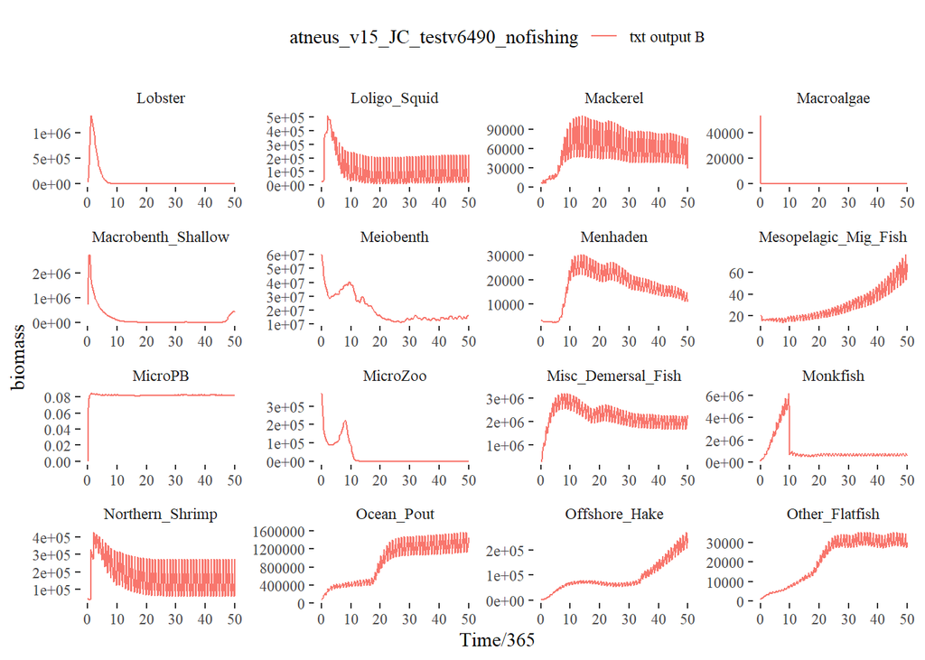

```r
plotB + ggforce::facet_wrap_paginate(~species, ncol=4, nrow = 4, page = 3, scales="free")
```

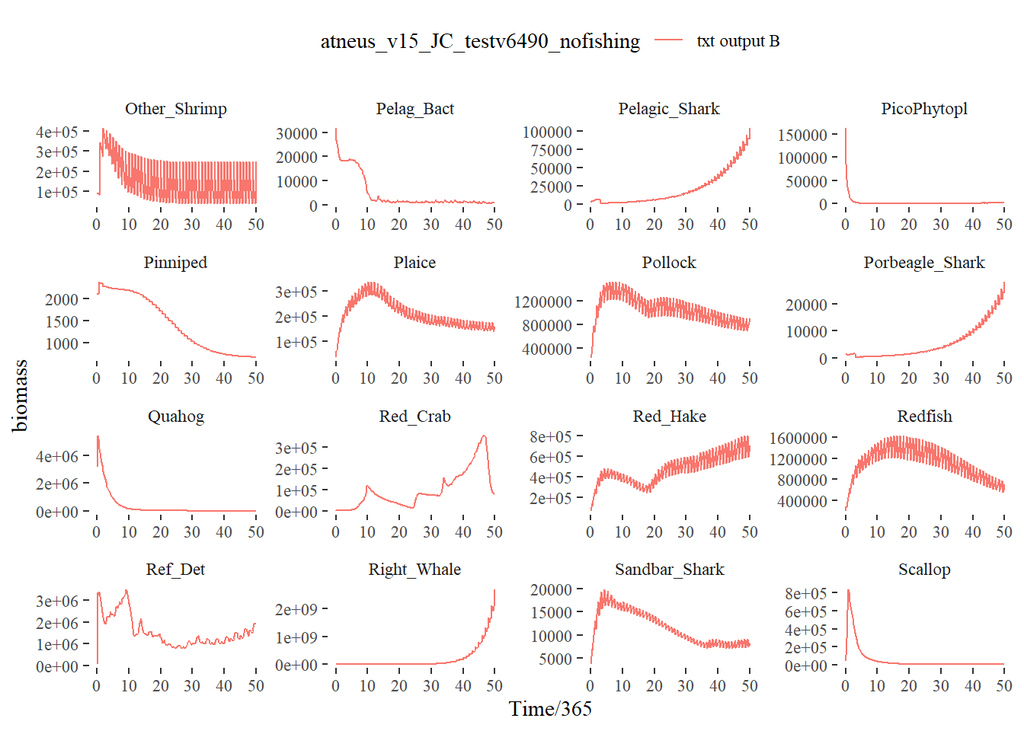

```r
plotB + ggforce::facet_wrap_paginate(~species, ncol=4, nrow = 4, page = 4, scales="free")
```

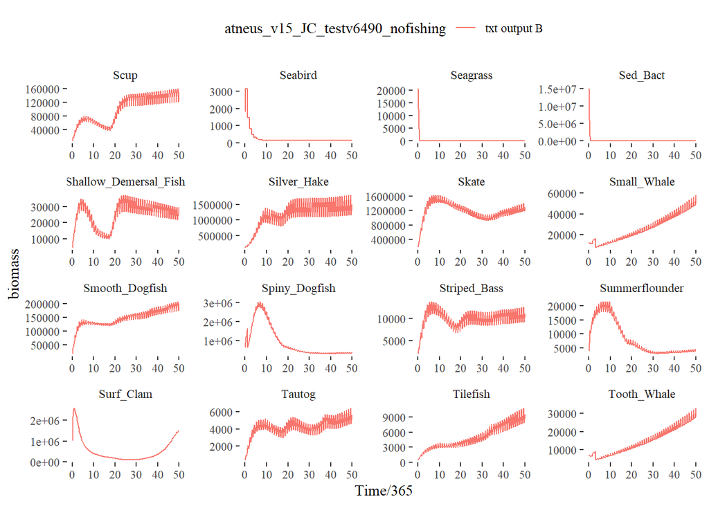

```r
plotB + ggforce::facet_wrap_paginate(~species, ncol=4, nrow = 4, page = 5, scales="free")
```

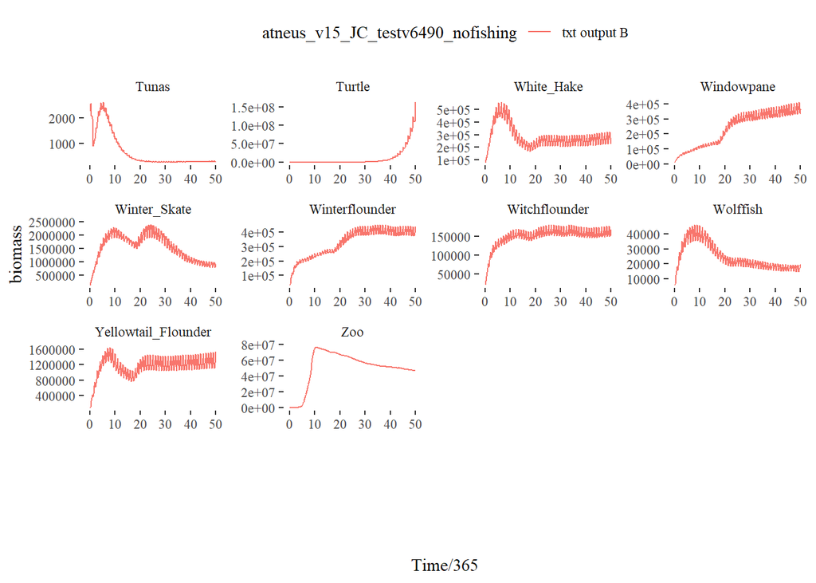

```r
plotB + ggforce::facet_wrap_paginate(~species, ncol=4, nrow = 4, page = 6, scales="free")
```

```r
# need in annual units? Or fail when any output timestep below threshold?
# make safe for migratory species, assume that over the course of the year mean B > 0.
# assumes biomass never goes negative in atlantis

crash <- atBtxttidy %>%
  group_by(species, yr) %>%
  summarise(meanB = mean(biomass)) %>%
  filter(meanB < 1e-4)

# flag any groups with any mean annual biomass below a threshold

unique(crash$species)
```

[output not shown]

### Stability test

Model reaches steady state for last ~20 years of an unperturbed, unfished ~100 year run. Things at 0 shouldn’t count, so run persistence test as well. For plotting, let’s skip the first 20 model years so we only look after spinup.

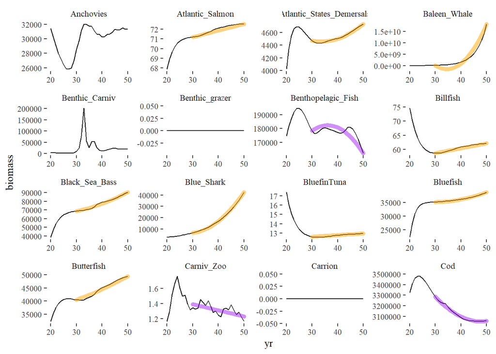

```
## Error in nlme::gls(y ~ 1, data = data, correlation = nlme::corAR1(form = ~x),  :
##   singular convergence (7)
```

```r
# read in long run from separate folder
longatBtxt <- read.table(file.path(here("diagnostics", "testfiles", "100_year_no_fishing"), paste0(scenario.name, "BiomIndx.txt")), header=T)
groupslookup <- funct.groups %>% #assumes we have the same functional groups in this run as the shorter ones
  filter(IsTurnedOn > 0)

# read in run pars for the long run too
longrunpar <- load_runprm(here("diagnostics", "testfiles", "50_year_no_fishing"), run.prm.file) #assumes same name as above, it is
longnoutsteps <- longrunpar$tstop/longrunpar$outputstep

longtimeall <- c(0:longnoutsteps)

longatBtxttidy <- longatBtxt %>%
  select(Time:DIN) %>%
  rename_(.dots=with(groupslookup, setNames(as.list(as.character(Code)), Name))) %>%
  gather(species, biomass, -Time) %>%
  mutate(yr = ceiling(Time/365))  %>%
  filter(Time %in% seq(20*365, floor(longrunpar$nyears)*365, by=365))


# look for non-significant slope over last 20 years? 30 years would be better
nlast <- 20

startlast <- floor(longrunpar$nyears)-nlast

#warning, was getting different behavior with this code on my linux machine

stable <- longatBtxttidy %>%
  filter(Time %in% seq(startlast*365, floor(longrunpar$nyears)*365, by=365)) %>%
  group_by(species) %>%
  ggplot(aes(x=yr, y=biomass)) +
  ggthemes::theme_tufte() +
  geom_line(data=longatBtxttidy, aes(x=yr, y=biomass)) +
  geom_gls(warn = FALSE)


stable + ggforce::facet_wrap_paginate(~species, ncol=4, nrow = 4, page = 1, scales="free")
```

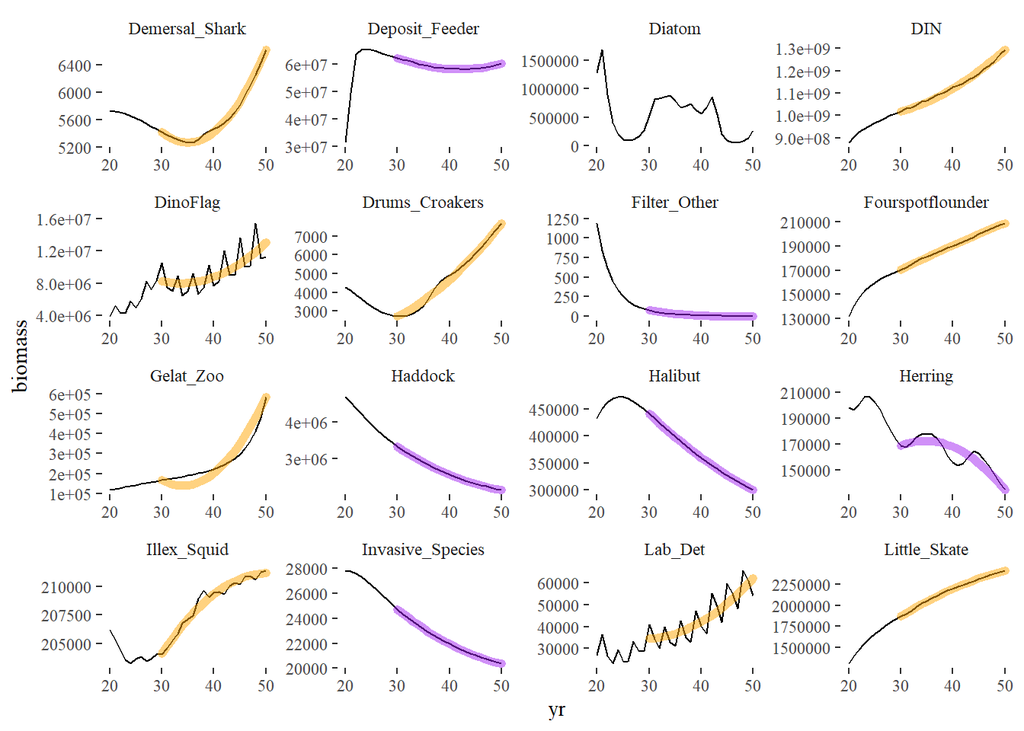

```
## Error in nlme::gls(y ~ 1, data = data, correlation = nlme::corAR1(form = ~x),  :
##   singular convergence (7)
```

```r
stable + ggforce::facet_wrap_paginate(~species, ncol=4, nrow = 4, page = 2, scales="free")
```

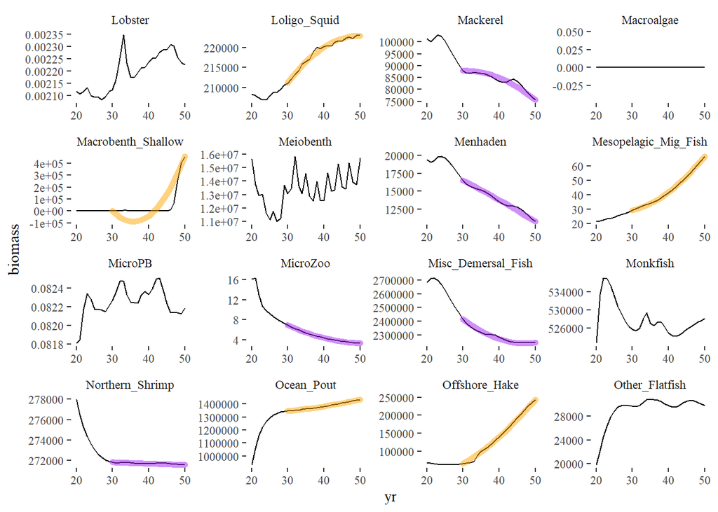

```
## Error in nlme::gls(y ~ 1, data = data, correlation = nlme::corAR1(form = ~x),  :
##   singular convergence (7)
```

```r
stable + ggforce::facet_wrap_paginate(~species, ncol=4, nrow = 4, page = 3, scales="free")
```

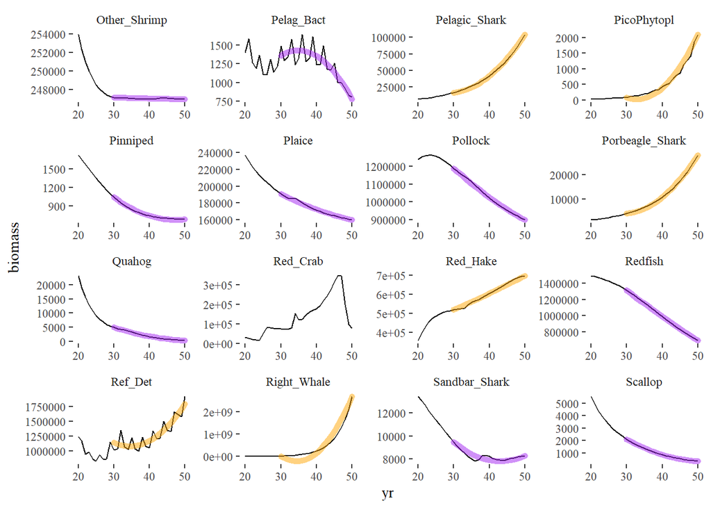

```
## Error in nlme::gls(y ~ 1, data = data, correlation = nlme::corAR1(form = ~x),  :
##   singular convergence (7)
```

```r
stable + ggforce::facet_wrap_paginate(~species, ncol=4, nrow = 4, page = 4, scales="free")
```

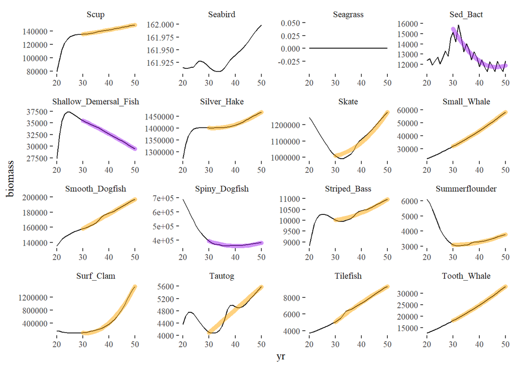

```
## Error in nlme::gls(y ~ 1, data = data, correlation = nlme::corAR1(form = ~x),  :
##   singular convergence (7)
```

```r
stable + ggforce::facet_wrap_paginate(~species, ncol=4, nrow = 4, page = 5, scales="free")
```

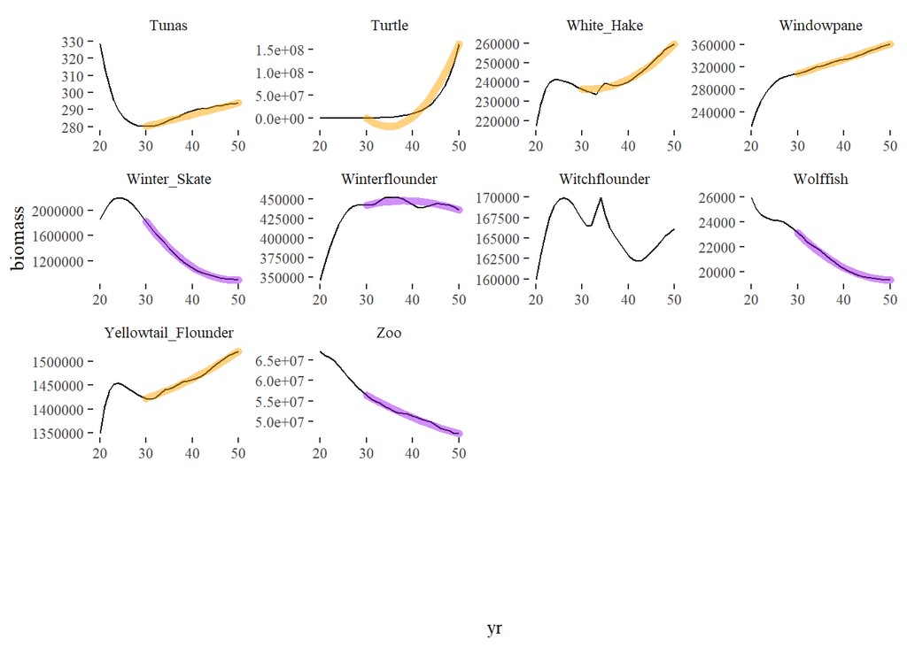

```
## Error in nlme::gls(y ~ 1, data = data, correlation = nlme::corAR1(form = ~x),  :
##   singular convergence (7)
```

```r
stable + ggforce::facet_wrap_paginate(~species, ncol=4, nrow = 4, page = 6, scales="free")
```

```r
# what I need is to extract the output of geom_gls that is NULL (no significant trend)

# this may work eventually but blows up R right now, fix later
# # get results from ecotrend package
# stabletest <- longatBtxttidy %>%
#   filter(Time %in% seq(startlast*365, floor(longrunpar$nyears)*365, by=365)) %>%
#   group_by(species) %>%
#   dplyr::do(ecotrend::glsMs(data = ., formula = yr ~ biomass))
#
# #ecotrend::glsMs(data = ., formula = yr ~ biomass)
#
# #ecotrend::glsMs(yr ~ biomass, stabletest)

#test this run for persistence too

longcrash <- longatBtxt %>%
  select(Time:DIN) %>%
  rename_(.dots=with(groupslookup, setNames(as.list(as.character(Code)), Name))) %>%
  gather(species, biomass, -Time) %>%
  mutate(yr = ceiling(Time/365))  %>%
  group_by(species, yr) %>%
  summarise(meanB = mean(biomass)) %>%
  filter(meanB < 1e-4)

# flag any groups with any mean annual biomass below a threshold

unique(longcrash$species)
```

[output not shown]

### Establish hindcast period

See discussion [here](https://github.com/NOAA-EDAB/atneus_RM/issues/7) and [here](https://github.com/NOAA-EDAB/atneus_RM/wiki/Meeting-minutes#20191002).

The period is defined as 1980-2010 for trend comparison. Change it here to see different results:

```r
hindcast <- c(1980:2010)
```

Data sources include ecodata and stock assessment outputs for major species.

### Interim step: which species to include and what data are in the reference set for comparison

Not all species need to match, we will first determine the most important subset(s). Based on discussion, we want to track the species the comprise 80% of biomass (and 80% of catch and 80% of revenue).

### Species qualitatively match trends

```r
# assumes biom.txt output already read in
```

## References

1. Kaplan IC, Marshall KN. A guinea pig’s tale: Learning to review end-to-end marine ecosystem models for management applications. ICES Journal of Marine Science. 2016;73: 1715–1724. doi:10.1093/icesjms/fsw047

2. Pethybridge HR, Weijerman M, Perrymann H, Audzijonyte A, Porobic J, McGregor V, et al. Calibrating process-based marine ecosystem models: An example case using Atlantis. Ecological Modelling. 2019;412: 108822. doi:10.1016/j.ecolmodel.2019.108822